# R Notebook

[figure not shown]

```r
NA
```

We try with IPSSR

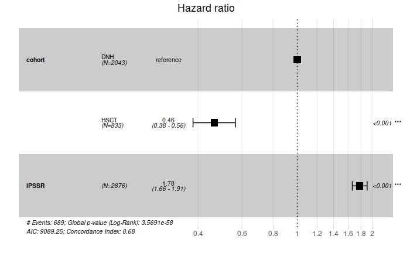

```r
cox.IPSSR = coxph(Surv(time, fup_status) ~ cohort + IPSSR, MDS_data)
# summary(cox.IPSSR)
ggforest(cox.IPSSR, data=MDS_data)
```

Using cohort + IPSSR as covariates it seems clear what we said before, namely that it’s important to consider the risk score of each patient since probably it’s higher for HSCT patients than for DNH ones (as in the following plot). Now cohort seems important and HSCT patients has the half of the risk wrt DNH patients.

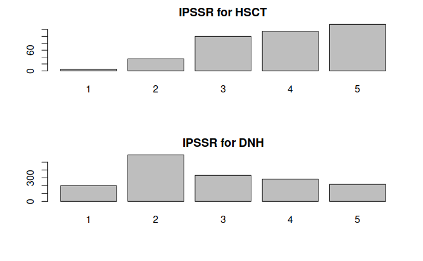

```r
layout(c(1,2))
plot(as.factor(IPSSR[which(cohort == "HSCT")]), main="IPSSR for HSCT")
plot(as.factor(IPSSR[which(cohort == "DNH")]), main="IPSSR for DNH")
```

```r
print(paste("IPSSR mean for HSCT:", mean(IPSSR[which(cohort == "HSCT")], na.rm = TRUE)))
```

```
[1] "IPSSR mean for HSCT: 3.87179487179487"
```

```r
print(paste("IPSSR mean for DNH:", mean(IPSSR[which(cohort == "DNH")], na.rm = TRUE)))
```

```
[1] "IPSSR mean for DNH: 2.83240911891559"
```

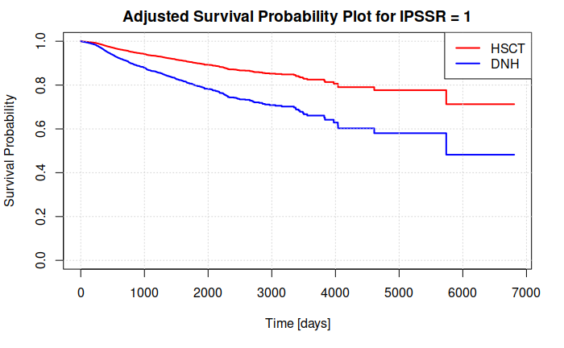

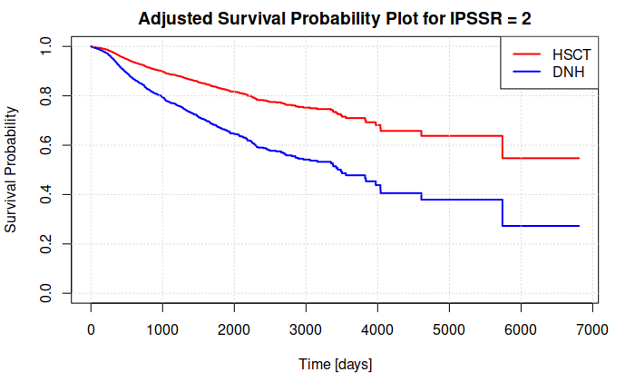

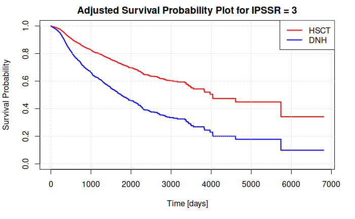

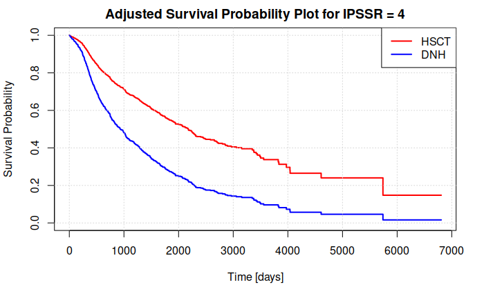

```r
for (i in 1:(length(levels(as.factor(IPSSR))))) {

  IPSSR_df <- with(MDS_data, data.frame(IPSSR = c(i),
                                        cohort = c("HSCT", "DNH")))

  fit.IPSSR <- survfit(cox.IPSSR, newdata = IPSSR_df)

  plot(fit.IPSSR, conf.int=F,
       col=c("red","blue"), lwd=2, lty=1,
       xlab="Time [days]", ylab="Survival Probability",
       main = paste("Adjusted Survival Probability Plot for IPSSR =", i))
  grid()
  legend('topright', c("HSCT", "DNH"),
         lty=c(1,1,1), lwd=c(2,2,2), col=c("red","blue"))
}
```

[figure not shown]

```r
NA
```

**Maybe it’s better to use IPSSR as categorical variable?**

**Maybe it’s better to also include the interaction between cohort and IPSSR?**

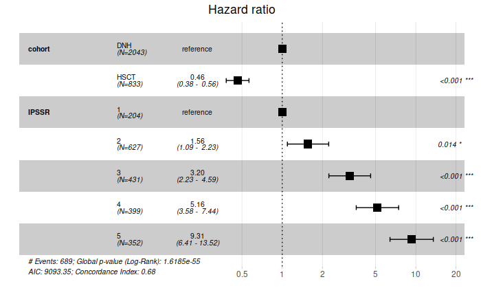

```r
MDS_data$IPSSR <- as.character(MDS_data$IPSSR)
cox.IPSSR = coxph(Surv(time, fup_status) ~ cohort + IPSSR, MDS_data)
# summary(cox.IPSSR)
ggforest(cox.IPSSR, data=MDS_data)
```

**If it’s better to use IPSSR as a numerical variable, what scale we can use? We can deduce it looking at the hazard ratios in the previous plot?**

Now we try a more complete model adding both genomic group and IPSSR and also age.

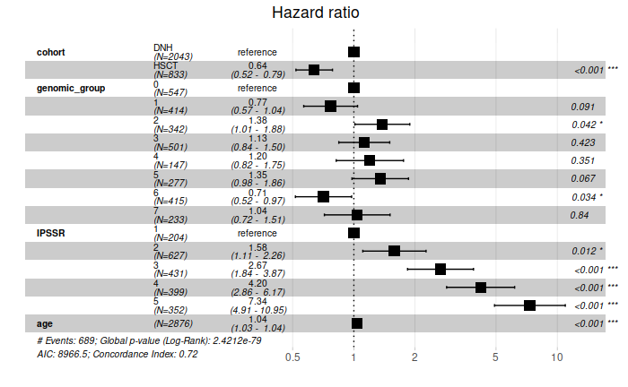

```r
cox.complete = coxph(Surv(time, fup_status) ~ cohort + genomic_group + IPSSR + age, MDS_data)
# summary(cox.complete)
ggforest(cox.complete, data=MDS_data)
```

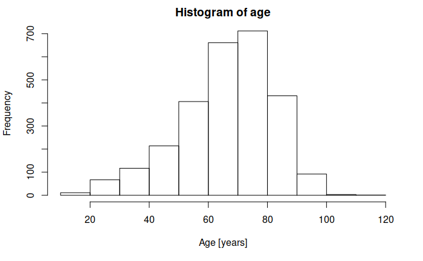

```r
hist(age, xlab='Age [years]', main='Histogram of age')
```

```r
# summary(age)

MDS_data$agecat69 <- cut(MDS_data$age, breaks=c(0, 69, Inf), labels=c("young", "old"))
```

It seems that cohort is important and its coefficient remains similar wrt the previous model. Age seems important since it has a very low P-value but it has exp(coef) = 1.0360. So, every year, the risk of a patient increases of 3.6% which is a significant ration. To see it better, maybe we can discretize age for example in 2 groups: “young” and “old” based on its median values which is 69

```r
cox.complete = coxph(Surv(time, fup_status) ~ cohort + genomic_group + IPSSR + agecat69, MDS_data)
summary(cox.complete)
```

```
Call:
coxph(formula = Surv(time, fup_status) ~ cohort + genomic_group +
    IPSSR + agecat69, data = MDS_data)

  n= 2013, number of events= 689
   (863 observations deleted due to missingness)

                   coef exp(coef) se(coef)      z Pr(>|z|)
cohortHSCT     -0.59488   0.55163  0.10425 -5.706 1.16e-08 ***
genomic_group1 -0.15248   0.85858  0.15502 -0.984   0.3253
genomic_group2  0.37665   1.45739  0.15856  2.375   0.0175 *
genomic_group3  0.21987   1.24592  0.14674  1.498   0.1340
genomic_group4  0.27808   1.32059  0.19408  1.433   0.1519
genomic_group5  0.37713   1.45809  0.16290  2.315   0.0206 *
genomic_group6 -0.22436   0.79903  0.16189 -1.386   0.1658
genomic_group7  0.17372   1.18972  0.18897  0.919   0.3580
IPSSR2          0.42986   1.53704  0.18286  2.351   0.0187 *
IPSSR3          0.96348   2.62081  0.19051  5.057 4.25e-07 ***
IPSSR4          1.39202   4.02295  0.19641  7.087 1.37e-12 ***
IPSSR5          1.92737   6.87141  0.20437  9.431  < 2e-16 ***
agecat69old     0.63249   1.88230  0.08555  7.393 1.43e-13 ***
---
Signif. codes:  0 ‘***’ 0.001 ‘**’ 0.01 ‘*’ 0.05 ‘.’ 0.1 ‘ ’ 1

               exp(coef) exp(-coef) lower .95 upper .95
cohortHSCT        0.5516     1.8128    0.4497    0.6767
genomic_group1    0.8586     1.1647    0.6336    1.1634
genomic_group2    1.4574     0.6862    1.0681    1.9886
genomic_group3    1.2459     0.8026    0.9345    1.6611
genomic_group4    1.3206     0.7572    0.9028    1.9318
genomic_group5    1.4581     0.6858    1.0596    2.0065
genomic_group6    0.7990     1.2515    0.5818    1.0974
genomic_group7    1.1897     0.8405    0.8215    1.7230
IPSSR2            1.5370     0.6506    1.0741    2.1995
IPSSR3            2.6208     0.3816    1.8042    3.8071
IPSSR4            4.0230     0.2486    2.7375    5.9119
IPSSR5            6.8714     0.1455    4.6034   10.2567
agecat69old       1.8823     0.5313    1.5917    2.2259

Concordance= 0.707  (se = 0.011 )
Likelihood ratio test= 345.2  on 13 df,   p=<2e-16
Wald test            = 349.2  on 13 df,   p=<2e-16
Score (logrank) test = 381.1  on 13 df,   p=<2e-16
```

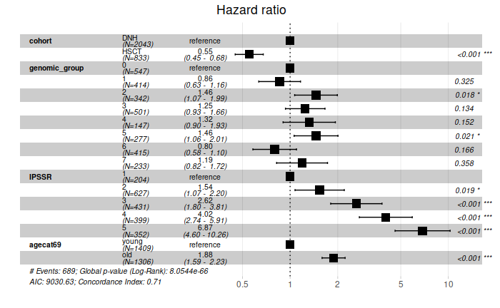

```r
ggforest(cox.complete, data=MDS_data)
```

Let’s verify the GOF of our model starting from the PH assumption.

H0: PH satisfied vs H1: PH not satisfied

```r
test.ph <- cox.zph(cox.complete)
test.ph
```

```
              chisq df       p
cohort        17.14  1 3.5e-05
genomic_group 18.95  7 0.00835
IPSSR         27.67  4 1.5e-05
agecat69       5.64  1 0.01757
GLOBAL        36.99 13 0.00042
```

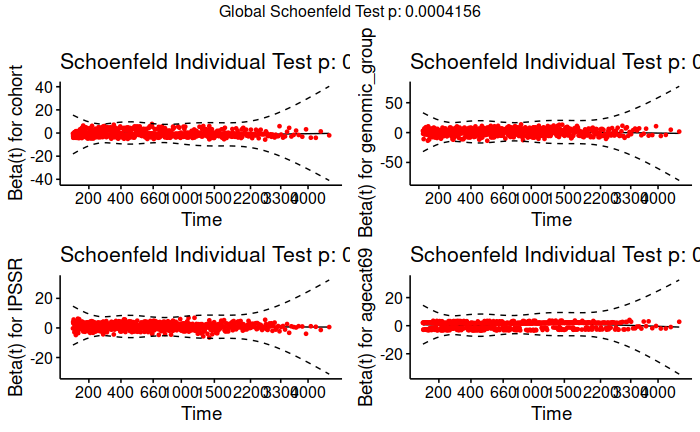

```r
ggcoxzph(test.ph)
```

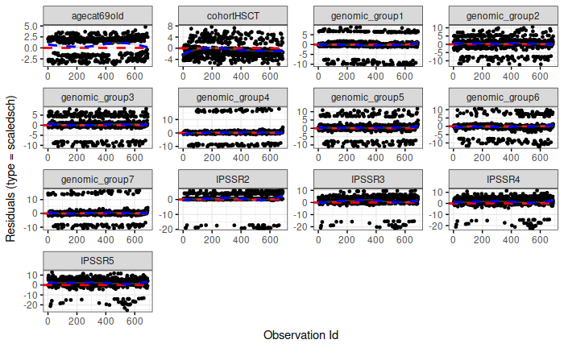

```r
# ggcoxdiagnostics(cox.complete, type = "schoenfeld")
ggcoxdiagnostics(cox.complete, type = "scaledsch") # scaled Schonefeld residuals
```

**We saw that p-values are very low so it seems that PH assumption is not satisfied. Is it true? In this case, is our Cox model anyway significant? Otherwise, can we use covariates which doesn’t satisfy PH assumption as time-dependent covariates or in a Cox model stratified on them?**

**We know there are other methods to asses non-linearity and other things, is this the case to enter into the details?**

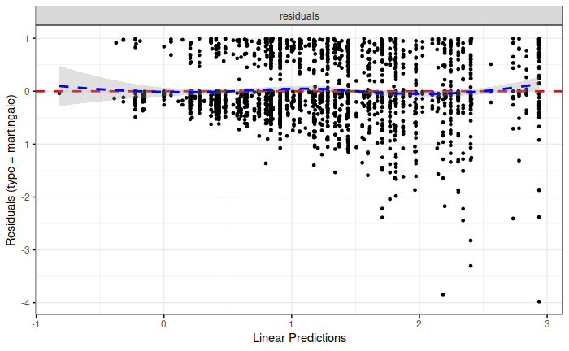

```r
ggcoxdiagnostics(cox.complete, type = "martingale") # to assess nonlinearity
```

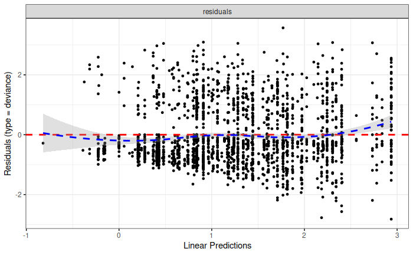

```r
ggcoxdiagnostics(cox.complete, type = "deviance") # (symmetric transformation of the Martinguale residuals), to examine influential observations
```

## Cox model with time-dependent covariates

**Can be this kind of Cox model a good way? Do we need to check also if we can include age at the transplantation as time dependent variable?**

## Landmark analysis

*Landmark analysis is an alternative for time dependent cox regression, isn’t it? Is Landmark Analysis appropriate for our case, considering the long term effect of investigating the response of the transplantation [https://doi.org/10.1161/CIRCOUTCOMES.110.957951]? In this reference it says “Thus, for example, the landmark analysis is a recognized useful tool for removing guarantee-time bias in the cases that response to treatment occurs early after starting treatment (eg, advanced colorectal cancer), whereas in cases in which response to treatment occurs over an extended period of time (eg, chronic leukemia), use of the landmark method is not indicated.19”.*